# NFL Wide Receiver Combine Analysis

2026-09-22

## Overview

**Question:** Do NFL Scouting Combine metrics predict a wide receiver’s career success, measured as Approximate Value (AV) per season?

**Data sources:**

- `data/sportsref_download.xlsx` — career stats for wide receivers drafted 2000 or later (Pro Football Reference / Stathead)
- `data/NFL_Combine_Since_2000.csv` — combine testing results, 2000–2025 (Kaggle: `isaaksipple/nfl-combine-2000-2025`)

The analysis below loads and merges these two sources, visualizes each combine metric against career AV per season, and fits a few linear regression models to see which metrics (if any) are meaningful predictors.

```r
library(dplyr)
library(ggplot2)
library(readr)
library(readxl)
library(stringr)
```

## 1. Load data

Read in the raw career-stats and combine-testing files.

```r
career_data <- read_excel("data/sportsref_download.xlsx")
combine_data <- read_csv("data/NFL_Combine_Since_2000.csv")
```

## 2. Filter to wide receivers

Both datasets cover every position, so we narrow each one down to wide receivers. On the career side we also drop anyone drafted before 2000, since that’s the range the combine data covers.

```r
combine_wr <- combine_data %>%
  filter(Position == "WR")

career_wr <- career_data %>%
  filter(Pos == "WR", From >= 2000)
```

## 3. Standardize player names for joining

Player names differ slightly between sources (periods, suffixes like Jr./II/III), so we normalize both sides before joining on name + draft year.

```r
clean_names <- function(x) {
  x %>%
    str_to_lower() %>%
    str_replace_all("\\.", "") %>%
    str_replace_all(" jr", "") %>%
    str_replace_all(" iii", "") %>%
    str_replace_all(" ii", "") %>%
    str_squish()
}

career_wr$Player <- clean_names(career_wr$Player)
combine_wr$Player <- clean_names(combine_wr$Player)
```

## 4. Merge career outcomes with combine testing data

Join on player name and draft year (`From` on the career side matches `Year` on the combine side), then clean up the resulting column names and derive `AV_per_season` — the outcome variable used throughout the rest of the analysis — as career AV divided by number of seasons played.

```r
merged_data <- inner_join(
  career_wr, combine_wr,
  by = c("Player", "From" = "Year")
) %>%
  distinct() %>%
  rename(
    Career_AV      = `AV...3`,
    Forty          = `40-yd Dash`,
    Vertical_Jump  = `Vertical Jump`,
    Bench_Press    = `Bench Press`,
    Broad_Jump     = `Broad Jump`,
    Cone_Drill     = `3-Cone Drill`,
    Shuttle        = `20-yd Shuttle`,
    Draft_Team     = Team.y
  ) %>%
  select(-Team.x, -Rk, -Position, -AV...9) %>%
  mutate(
    Seasons       = To - From + 1,
    AV_per_season = Career_AV / Seasons
  )

combine_metrics <- c("Forty", "Vertical_Jump", "Bench_Press",
                      "Broad_Jump", "Cone_Drill", "Shuttle")

merged_data[combine_metrics] <- lapply(merged_data[combine_metrics], as.numeric)

cat("Merged dataset:", nrow(merged_data), "wide receivers\n")
```

```
Merged dataset: 612 wide receivers
```

## 5. Visualize each combine metric vs. career performance

For each combine metric we plot AV per season against that metric with a linear trend line. Timed drills (40-yard dash, 3-cone, shuttle) have their x-axis reversed, since a *lower* time is the better athletic outcome — this keeps “better performance” pointing the same direction (right) across every plot.

```r
combine_untimed_metrics <- c("Vertical_Jump", "Bench_Press", "Broad_Jump")
combine_timed_metrics   <- c("Forty", "Cone_Drill", "Shuttle")

dir.create("plots", showWarnings = FALSE)

for (metric in combine_untimed_metrics) {
  p <- ggplot(merged_data, aes(x = .data[[metric]], y = AV_per_season)) +
    geom_point(alpha = 0.5) +
    geom_smooth(method = "lm", se = FALSE) +
    labs(title = paste(metric, "vs AV Per Season"), x = metric, y = "AV Per Season")
  ggsave(filename = paste0("plots/", metric, "_vs_AV.png"), plot = p, width = 8, height = 6)
}

for (metric in combine_timed_metrics) {
  # Lower (faster) times are better, so the x-axis is reversed for readability
  p <- ggplot(merged_data, aes(x = .data[[metric]], y = AV_per_season)) +
    geom_point(alpha = 0.5) +
    geom_smooth(method = "lm", se = FALSE) +
    scale_x_reverse() +
    labs(title = paste(metric, "vs AV Per Season"), x = metric, y = "AV Per Season")
  ggsave(filename = paste0("plots/", metric, "_vs_AV.png"), plot = p, width = 8, height = 6)
}
```

The loop above saves each plot as a PNG to `plots/` (useful for reuse elsewhere), but doesn’t display them inline in this report. The chunk below renders each one directly in the knitted document so the plots and their regression context sit together.

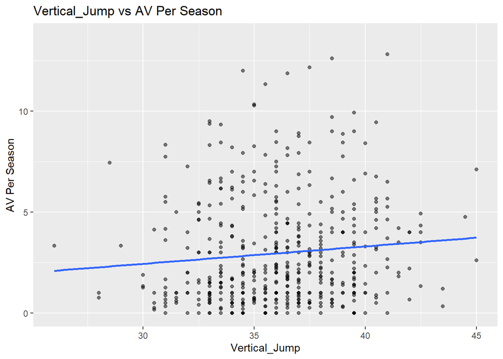

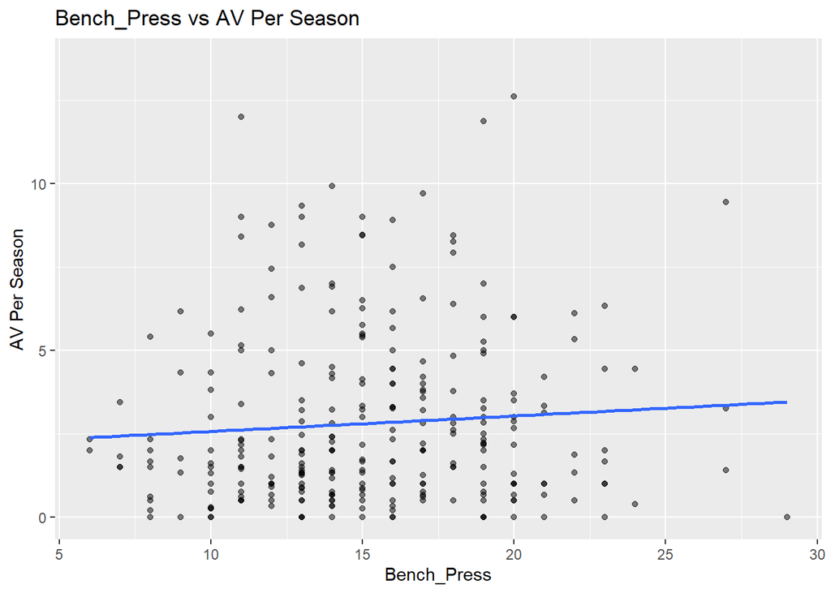

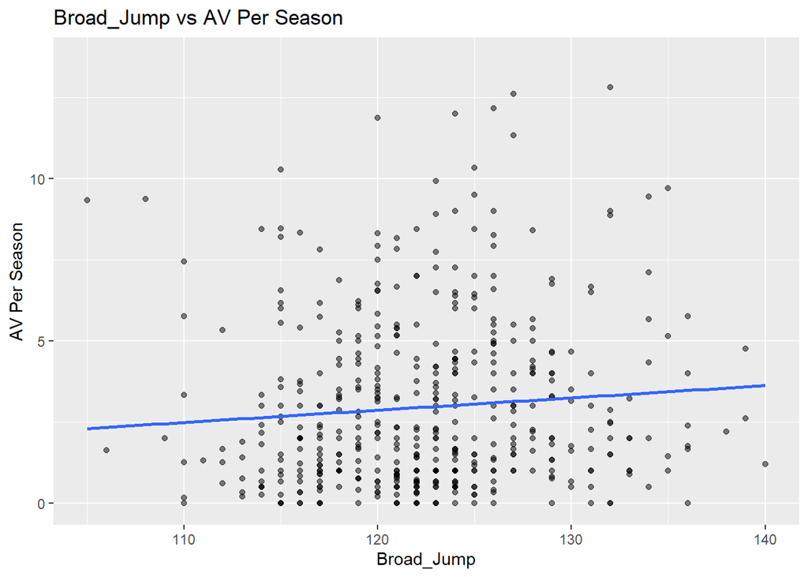

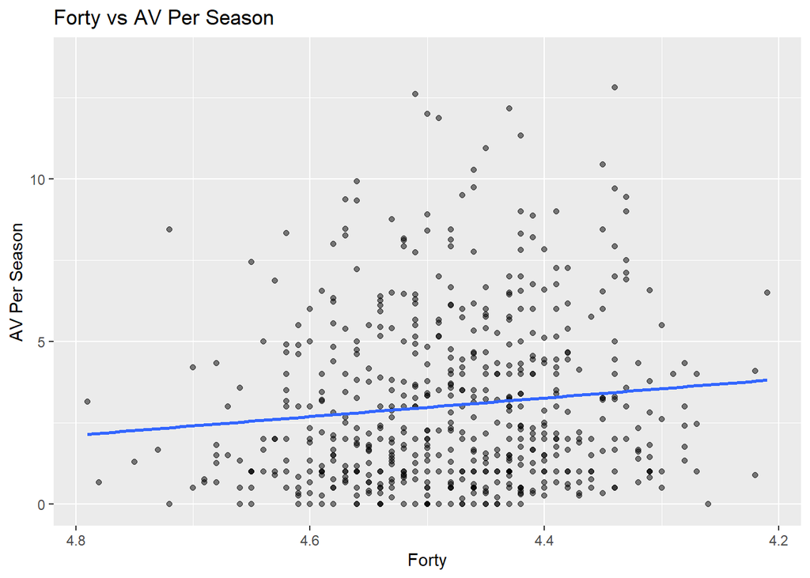

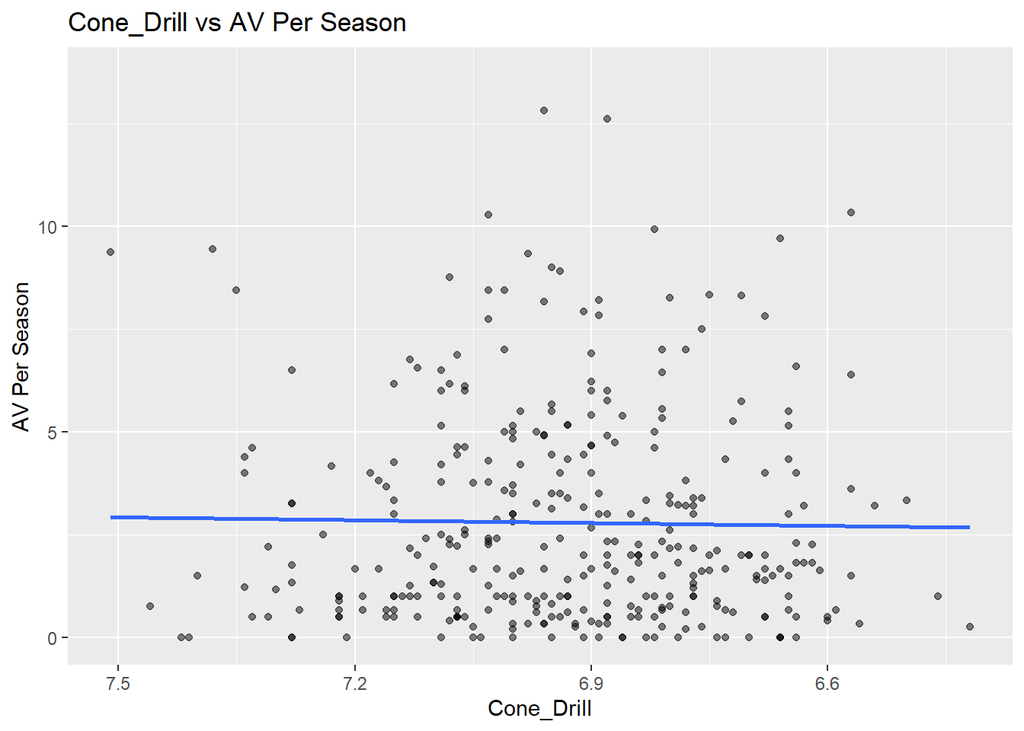

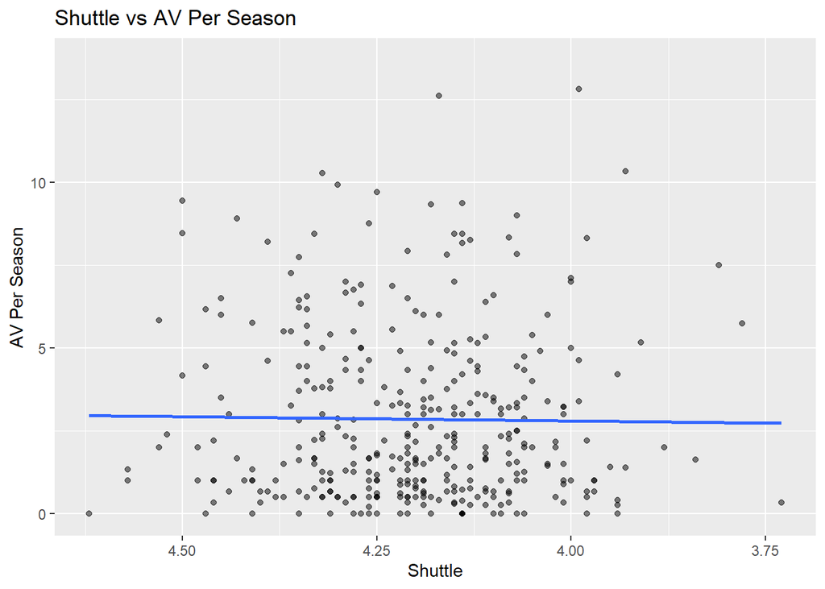

```r
for (metric in c(combine_untimed_metrics, combine_timed_metrics)) {
  reverse_axis <- metric %in% combine_timed_metrics
  p <- ggplot(merged_data, aes(x = .data[[metric]], y = AV_per_season)) +
    geom_point(alpha = 0.5) +
    geom_smooth(method = "lm", se = FALSE) +
    labs(title = paste(metric, "vs AV Per Season"), x = metric, y = "AV Per Season")
  if (reverse_axis) p <- p + scale_x_reverse()
  print(p)
}
```

## 6. Regression models

Three linear models test different subsets of combine metrics as predictors of `AV_per_season`:

- **Full model** — all six combine metrics together
- **Speed model** — just the three timed drills (40-yard dash, shuttle, 3-cone)
- **Explosion model** — just the two jump metrics (vertical, broad)

For each, `summary()` reports the coefficient estimates, their standard errors, t-values, and p-values (is each metric individually a significant predictor once the others are accounted for), along with the model’s overall R-squared (how much of the variance in AV per season the model explains) and F-statistic (whether the model as a whole is a significant predictor).

```r
full_model <- lm(
  AV_per_season ~ Forty + Vertical_Jump + Bench_Press + Broad_Jump + Cone_Drill + Shuttle,
  data = merged_data
)
summary(full_model)
```

```
Call:
lm(formula = AV_per_season ~ Forty + Vertical_Jump + Bench_Press +
    Broad_Jump + Cone_Drill + Shuttle, data = merged_data)

Residuals:
    Min      1Q  Median      3Q     Max
-4.0869 -1.9235 -0.6759  1.1579  9.5697

Coefficients:
               Estimate Std. Error t value Pr(>|t|)
(Intercept)   -1.059383  13.735030  -0.077    0.939
Forty         -2.339964   2.302349  -1.016    0.311
Vertical_Jump  0.052739   0.085065   0.620    0.536
Bench_Press    0.058280   0.047689   1.222    0.223
Broad_Jump    -0.003508   0.041540  -0.084    0.933
Cone_Drill     0.724065   1.296431   0.559    0.577
Shuttle        1.657267   1.721826   0.963    0.337

Residual standard error: 2.578 on 175 degrees of freedom
  (430 observations deleted due to missingness)
Multiple R-squared:  0.03807,   Adjusted R-squared:  0.005091
F-statistic: 1.154 on 6 and 175 DF,  p-value: 0.3331
```

```r
speed_model <- lm(
  AV_per_season ~ Forty + Shuttle + Cone_Drill,
  data = merged_data
)
summary(speed_model)
```

```
Call:
lm(formula = AV_per_season ~ Forty + Shuttle + Cone_Drill, data = merged_data)

Residuals:
    Min      1Q  Median      3Q     Max
-3.3795 -2.0281 -0.7535  1.2664  9.8984

Coefficients:
            Estimate Std. Error t value Pr(>|t|)
(Intercept)   8.3018     7.9207   1.048   0.2954
Forty        -2.6015     1.5323  -1.698   0.0905 .
Shuttle      -0.1654     1.1704  -0.141   0.8877
Cone_Drill    0.9916     0.8488   1.168   0.2436
---
Signif. codes:  0 '***' 0.001 '**' 0.01 '*' 0.05 '.' 0.1 ' ' 1

Residual standard error: 2.563 on 319 degrees of freedom
  (289 observations deleted due to missingness)
Multiple R-squared:  0.01168,   Adjusted R-squared:  0.002389
F-statistic: 1.257 on 3 and 319 DF,  p-value: 0.2892
```

```r
explosion_model <- lm(
  AV_per_season ~ Vertical_Jump + Broad_Jump,
  data = merged_data
)
summary(explosion_model)
```

```
Call:
lm(formula = AV_per_season ~ Vertical_Jump + Broad_Jump, data = merged_data)

Residuals:
   Min     1Q Median     3Q    Max
-3.500 -1.998 -0.836  1.395  9.424

Coefficients:
              Estimate Std. Error t value Pr(>|t|)
(Intercept)   -1.56465    2.54791  -0.614    0.539
Vertical_Jump  0.05189    0.05162   1.005    0.315
Broad_Jump     0.02160    0.02648   0.816    0.415

Residual standard error: 2.622 on 466 degrees of freedom
  (143 observations deleted due to missingness)
Multiple R-squared:  0.009333,  Adjusted R-squared:  0.005081
F-statistic: 2.195 on 2 and 466 DF,  p-value: 0.1125
```

**Reading these results:** look at each model’s R-squared to see how much of the spread in career AV per season it accounts for, and check which individual predictors have p-values below 0.05 (conventionally “significant”) to see whether any single combine metric stands out. Given these are raw combine numbers predicting a noisy, multi-year career outcome, don’t expect a very high R-squared — the interesting part is usually the *relative* pattern across the three models (e.g., does the speed model or the explosion model explain more, and does any individual metric hold up once the others are controlled for).

## 7. Combined explosion score

As a follow-up, we combine vertical jump and broad jump into a single “Explosion Score” and plot it against career AV per season.

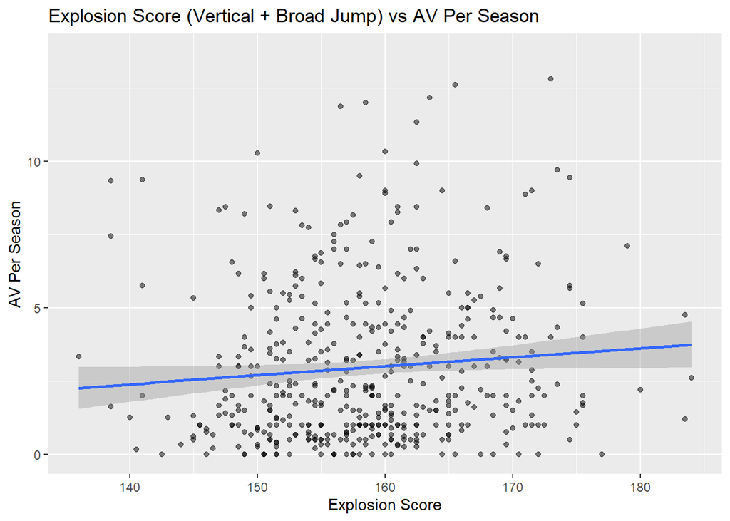

```r
merged_data <- merged_data %>%
  mutate(Explosion_Score = Vertical_Jump + Broad_Jump)

explosion_plot <- ggplot(merged_data, aes(x = Explosion_Score, y = AV_per_season)) +
  geom_point(alpha = 0.5) +
  geom_smooth(method = "lm") +
  labs(
    title = "Explosion Score (Vertical + Broad Jump) vs AV Per Season",
    x = "Explosion Score",
    y = "AV Per Season"
  )
ggsave("plots/Explosion_Score_vs_AV.png", plot = explosion_plot, width = 8, height = 6)

explosion_plot
```

## Summary

This report walked through: merging combine testing data with career outcomes for WRs drafted since 2000, visualizing each combine metric against career AV per season, and fitting three regression models (full, speed-only, explosion-only) to test which combine metrics best predict career success. The regression tables above are the core results — refer to each model’s R-squared and per-metric p-values to judge which combine metrics, if any, carry predictive signal for WR career performance.